[figure not shown]

### Trabajo final para semillero DSRP 2022-2 por Kharen Benavides

# Que es Pokemon?

Es una franquicia de medios que originalmente comenzó como un videojuego, pero debido a su popularidad ha logrado expandirse a otros medios de entretenimiento como series de televisión, películas, juegos de cartas, ropa, entre otros, convirtiéndose en una marca que es reconocida en el mercado mundial.

Pókemon, el anime, por su nombre original Pocket monsters es un anime creado por Satoshi Tajiri, Junichi Masuda y Ken Sugimori basado de los videojuegos de pokemón. Narra la vida de un muchacho, Ash Ketchum, un adolescente proveniente del Pueblo Paleta, que desea cumplir su sueño: ser un maestro pokemon.

Este anime fue emitido por primera vez el 1 de abril de 1997. La primera temporada cuenta con 276 episodios presentando personajes como Brock, Misty y el equipo Rocket

# Por que usar Data Pokemon?

Al ser tan popular cuenta con informacion de conocimiento publico sobre las caracteristicas de cada pokemon, ademas de presentar una gran variabilidad en los [datos](https://www.wikidex.net/wiki/Lista_de_Pok%C3%A9mon_con_sus_caracter%C3%ADsticas_base) que permite hacer diversos estudios, en este caso la base de datos se obtuvo del Github de [Angel Rene Segura](https://github.com/Alejandro-FB/Curso-Ciencia-Datos), y cuenta con 800 filas,representando los diferentes pokemones que existen con sus nombres y números de [Pokédex](https://www.pokemon.com/el/pokedex/), cabe recalcar que la lista llega hasta la temporada número 6. Cada uno de estos viene acompañado de 13 columnas, que representan las diferentes características de cada uno:

1. **Number:** *Número del pokemon en la pokedex*
2. **Name:** *Nombre del pokemon*
3. **Type 1:** *Tipo 1 de pokemon*
4. **Type 2:** *Tipo 2 de pokemon*
5. **Total:** *Total de las estadísticas base.(Mayor total, mejor pokemon)*
6. **HP:** *Puntos de salud Los puntos de salud (Health Points)*
7. **Attack:** *Ataque*
8. **Defense:** *Defensa*
9. **Sp. Atk:** *Fuerza de ataque especial*
10. **Sp. Def:** *Fuerza de defensa espacial*
11. **Speed:** *Velocidad*
12. **Generation:** *Generacion*
13. **Legendary:** *Es legendario o no*

# Analisis de Data

Datos

```
##   X.                  Name Type.1 Type.2 Total HP Attack Defense Sp..Atk
## 1  1             Bulbasaur  Grass Poison   318 45     49      49      65
## 2  2               Ivysaur  Grass Poison   405 60     62      63      80
## 3  3              Venusaur  Grass Poison   525 80     82      83     100
## 4  3 VenusaurMega Venusaur  Grass Poison   625 80    100     123     122
## 5  4            Charmander   Fire          309 39     52      43      60
## 6  5            Charmeleon   Fire          405 58     64      58      80
##   Sp..Def Speed Generation Legendary
## 1      65    45          1     False
## 2      80    60          1     False
## 3     100    80          1     False
## 4     120    80          1     False
## 5      50    65          1     False
## 6      65    80          1     False
```

Resumen de los datos

```
##        X.            Name              Type.1             Type.2
##  Min.   :  1.0   Length:800         Length:800         Length:800
##  1st Qu.:184.8   Class :character   Class :character   Class :character
##  Median :364.5   Mode  :character   Mode  :character   Mode  :character
##  Mean   :362.8
##  3rd Qu.:539.2
##  Max.   :721.0
##      Total             HP             Attack       Defense
##  Min.   :180.0   Min.   :  1.00   Min.   :  5   Min.   :  5.00
##  1st Qu.:330.0   1st Qu.: 50.00   1st Qu.: 55   1st Qu.: 50.00
##  Median :450.0   Median : 65.00   Median : 75   Median : 70.00
##  Mean   :435.1   Mean   : 69.26   Mean   : 79   Mean   : 73.84
##  3rd Qu.:515.0   3rd Qu.: 80.00   3rd Qu.:100   3rd Qu.: 90.00
##  Max.   :780.0   Max.   :255.00   Max.   :190   Max.   :230.00
##     Sp..Atk          Sp..Def          Speed          Generation
##  Min.   : 10.00   Min.   : 20.0   Min.   :  5.00   Min.   :1.000
##  1st Qu.: 49.75   1st Qu.: 50.0   1st Qu.: 45.00   1st Qu.:2.000
##  Median : 65.00   Median : 70.0   Median : 65.00   Median :3.000
##  Mean   : 72.82   Mean   : 71.9   Mean   : 68.28   Mean   :3.324
##  3rd Qu.: 95.00   3rd Qu.: 90.0   3rd Qu.: 90.00   3rd Qu.:5.000
##  Max.   :194.00   Max.   :230.0   Max.   :180.00   Max.   :6.000
##   Legendary
##  Length:800
##  Class :character
##  Mode  :character
##
##
##
```

# Tipo de pokemon

```
## tipo
##      Bug     Dark   Dragon Electric    Fairy Fighting     Fire   Flying
##       69       31       32       44       17       27       52        4
##    Ghost    Grass   Ground      Ice   Normal   Poison  Psychic     Rock
##       32       70       32       24       98       28       57       44
##    Steel    Water
##       27      112
```

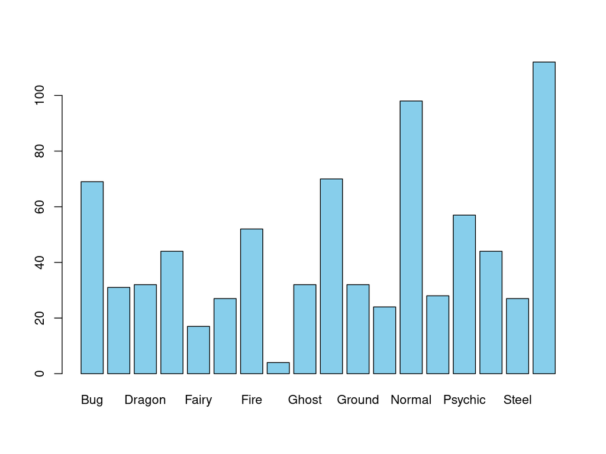

Con ayuda de la tabla de frecuencia absoluta y la grafica de los tipos, se puede evidenviar que hasta la 6ta temporada el pokemon predominante es tipo agua

# Gracias por su atención

[figure not shown]